# [BBC News: Cheeky boar leaves nudist grunting in laptop chase](https://www.bbc.co.uk/news/world-europe-53692475)

Published

August 7, 2020

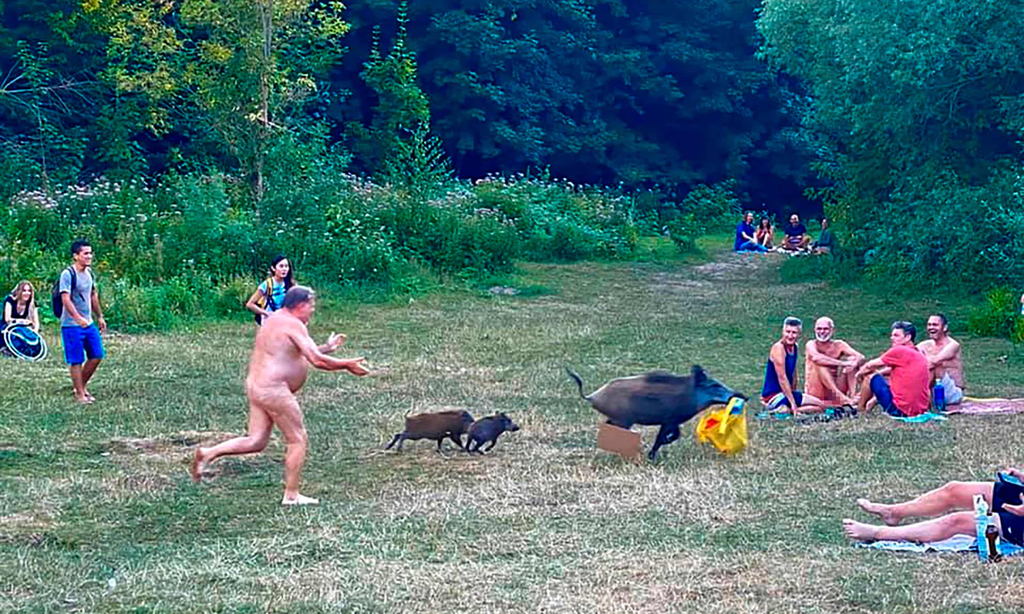

Figure 1: Photo by Adele landauer

# Cheeky boar leaves nudist grunting in laptop chase

**A nudist in Berlin got too close to nature for comfort when a wild boar snatched his plastic bag - which had his laptop inside.**  
The naked man gave chase to the boar and her two piglets - much to the amusement of fellow sunbathers.  
Adele Landauer, an actor and life coach, took photos of the chase at Teufelssee - a popular bathing spot - and put them on Facebook.  
“Nature strikes back!” she wrote, adding that the man laughed it all off.  
“He gave it his all”, with not a stitch on, she reported. “I then showed the photos to the man, he laughed soundly and authorised me to make them public.”

**Expand to see font name**

PDF Font: EB Garamond Most preferred 32/350

# Cheeky boar leaves nudist grunting in laptop chase

**A nudist in Berlin got too close to nature for comfort when a wild boar snatched his plastic bag - which had his laptop inside.**  
The naked man gave chase to the boar and her two piglets - much to the amusement of fellow sunbathers.  
Adele Landauer, an actor and life coach, took photos of the chase at Teufelssee - a popular bathing spot - and put them on Facebook.  
“Nature strikes back!” she wrote, adding that the man laughed it all off.  
“He gave it his all”, with not a stitch on, she reported. “I then showed the photos to the man, he laughed soundly and authorised me to make them public.”

**Expand to see font name**

Newsprint Font: Franklin Gothic Most preferred by 3 out 350 people (the worst score).

# Cheeky boar leaves nudist grunting in laptop chase

**A nudist in Berlin got too close to nature for comfort when a wild boar snatched his plastic bag - which had his laptop inside.**  
The naked man gave chase to the boar and her two piglets - much to the amusement of fellow sunbathers.  
Adele Landauer, an actor and life coach, took photos of the chase at Teufelssee - a popular bathing spot - and put them on Facebook.  
“Nature strikes back!” she wrote, adding that the man laughed it all off.  
“He gave it his all”, with not a stitch on, she reported. “I then showed the photos to the man, he laughed soundly and authorised me to make them public.”

**Expand to see font name**

Web Font: Oswald Most preferred 10/350

# Cheeky boar leaves nudist grunting in laptop chase

**A nudist in Berlin got too close to nature for comfort when a wild boar snatched his plastic bag - which had his laptop inside.**  
The naked man gave chase to the boar and her two piglets - much to the amusement of fellow sunbathers.  
Adele Landauer, an actor and life coach, took photos of the chase at Teufelssee - a popular bathing spot - and put them on Facebook.  
“Nature strikes back!” she wrote, adding that the man laughed it all off.  
“He gave it his all”, with not a stitch on, she reported. “I then showed the photos to the man, he laughed soundly and authorised me to make them public.”

**Expand to see font name**

Web Font: Roboto Most preferred 13/350

# Cheeky boar leaves nudist grunting in laptop chase

**A nudist in Berlin got too close to nature for comfort when a wild boar snatched his plastic bag - which had his laptop inside.**  
The naked man gave chase to the boar and her two piglets - much to the amusement of fellow sunbathers.  
Adele Landauer, an actor and life coach, took photos of the chase at Teufelssee - a popular bathing spot - and put them on Facebook.  
“Nature strikes back!” she wrote, adding that the man laughed it all off.  
“He gave it his all”, with not a stitch on, she reported. “I then showed the photos to the man, he laughed soundly and authorised me to make them public.”

**Expand to see font name**

Readability Font: Noto Sans Most preferred 52/350 (Joint winner with Times)